# Navigation Check - TORS

TORS (Transients Observation Recommendation System)

Team : STARTORS  
Team Members:

- Aseem Gosain
- Devansh Shrestha
- Lakshay Chawla
- Rommel Jalasutram

Welcome to TORS (Transients Observation Recommendation System), a reinforcement learning based recommendation system for space observations. Our system is designed to optimize observations of variable stars, such as cepheids and rrlyraes, by intelligently selecting telescopes and pointing directions. By utilizing reinforcement learning, TORS can adapt to changing observational conditions and make informed decisions to maximize scientific returns.

[figure not shown]

Let's Get Started ! 🏃🏻‍♂️

- **Problem Statement**

  The objective of this project is to develop a reinforcement learning-based recommendation system for astronomical observations of variable stars. The proposed system will analyze time series photometry data of variable stars and recommend the most suitable type of observation for each star.
- **Dataset Used**

  We aim to incorporate data from multiple surveys. Some of them are listed below:
  - GAIA DR3
  - ZTF DR16
  - Stripe 82
  - Hubble
  - ....

  To start with we have extracted the data of photometry data of variable stars from GAIA DR3. The classes we will be working with are:
  - Cepheid
  - RRLyrae
  - Eclipsing Binary
  - Long Period Variable
- **Inspiration**

  Just like every other child, when we were kids, we were fascinated by the endless sky and the innumerable number of stars that are unexplored (yet).  
  Always wanted to know more about stars and do something with astronomical data steered our team to take up a project using astronomical data.  
  Having an in-house expert – Professor Ignacio Becker motivated us further and we took upon this challenge.  
  Here is a link of research paper that inspired the project - [A Reinforcement Learning–Based Follow-up Framework](https://iopscience.iop.org/article/10.3847/1538-3881/acb0c3)
- **Data Extraction**

  Here's how data from GAIA DR3 was extracted:
  1. Get the object ids and positions of stars using ADQL queries.
  2. Merge all the files.
  3. From the photometry section of bulk downloads, extract all the links.
  4. Read all the files from the links, filter them using the merged file to get only required objects.
  5. Save the required objects in a tfrecrod file format.

  To get started with the next data source, we extracted all the links for photometry data from ZTF DR16, which will be incorporated soon.
- **RL Environment**

  The RL environment will be designed with different states, each containing details of different band data and metadata. We will make the variables XM, XRP, XG, and XBP. The actions of the environment will be defined as the recommendation for observing the specific star from n number of surveys, and the observation can be single band, multiband (which will affect cost), or no observation at all. The reward will be set as the probability of finding the object at state (St+1) - the probability of finding the object at state (St) - cost. The cost function will depend on different bands and surveys and will be formalized after data extraction.

Data Extraction

ADQL Queries

SELECT s.solution_id, s.source_id, s.ra, s.dec FROM gaiadr3.gaia_source AS s JOIN gaiadr3.vari_cepheid as v USING(source_id) WHERE s.source_id = v.source_id

SELECT s.solution_id, s.source_id, s.ra, s.dec FROM gaiadr3.gaia_source AS s JOIN gaiadr3.vari_long_period_variable as v USING(source_id) WHERE s.source_id = v.source_id

SELECT s.solution_id, s.source_id, s.ra, s.dec FROM gaiadr3.gaia_source AS s JOIN gaiadr3.vari_eclipsing_binary as v USING(source_id) WHERE s.source_id = v.source_id

SELECT s.solution_id, s.source_id, s.ra, s.dec FROM gaiadr3.gaia_source AS s JOIN gaiadr3.vari_rrlyrae as v USING(source_id) WHERE s.source_id = v.source_id

The following code reads all the csv files downloaded form the ADQL queries for GAIA DR3 and merge all of them in one dataframe saving it as a parquet file.

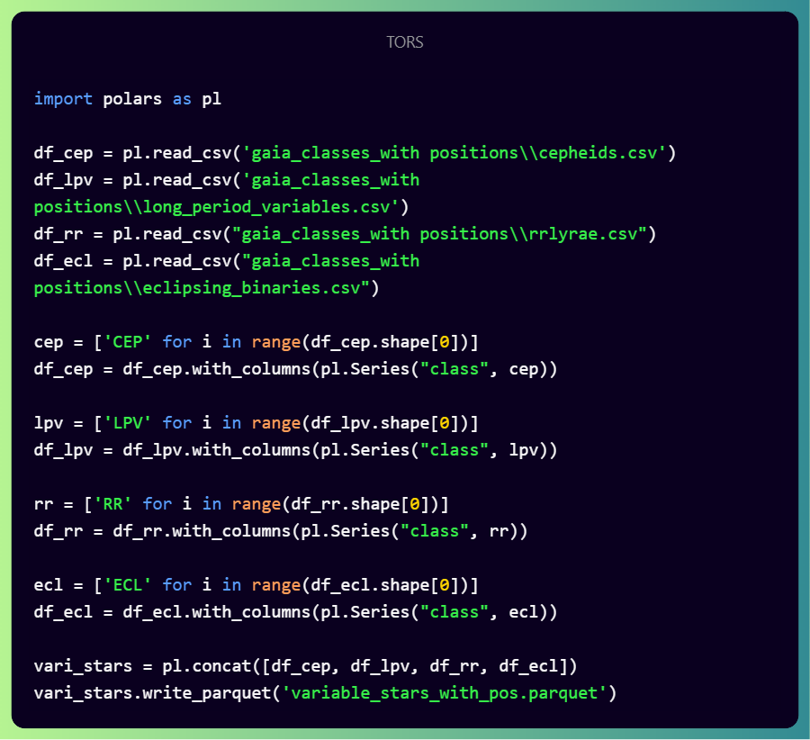

Here we extract all the links for the photometry data present in ZTF DR16 usind requests library and BeautifulSoup.

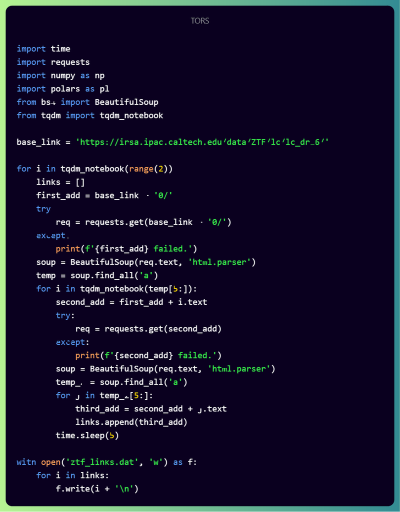

Eval Function

To convert a list present in form of a string to a list of float/integer values, we can use eval function. The problem with using eval function is that it does not support NaN values, so here we define a custom eval function that substitutes 999 for NaN values and then converts it to a list.

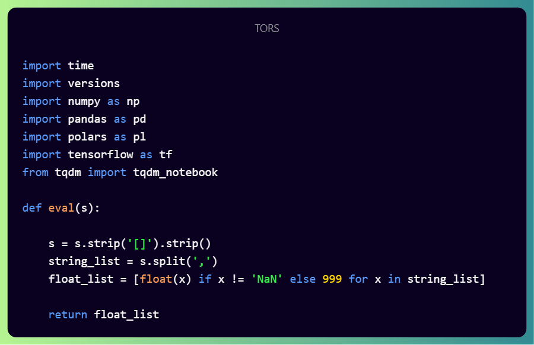

Class Tors

To make a proper data pipeline, using classes is the way to go. Here, we start by defining a class TORS.

Serialize a given dictionary containing Gaia data into a TensorFlow SequenceExample format.  
Args:

- dictionary (dict): A dictionary containing Gaia data with keys as follows:
- 'source_id': Unique source identifier
- 'ra': Right Ascension
- 'dec': Declination
- 'class': Star classification
- 'transit_id': A list of transit identifiers
- 'g_obs_time': A list of G-band observation times
- 'g_mag': A list of G-band magnitudes
- 'bp_obs_time': A list of BP-band observation times
- 'bp_mag': A list of BP-band magnitudes
- 'rp_obs_time': A list of RP-band observation times
- 'rp_mag': A list of RP-band magnitudes

Returns:  
A SequenceExample object containing the serialized Gaia data.

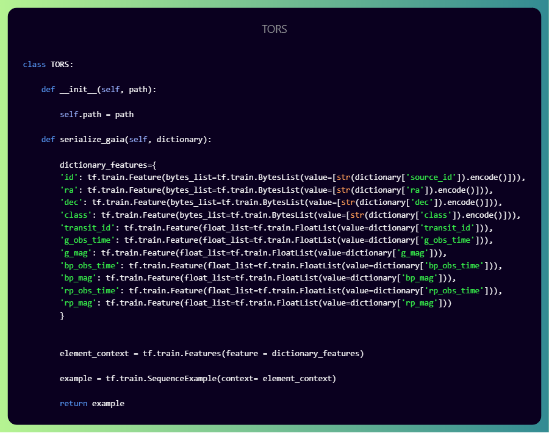

Reads Gaia data files from given links, processes the data, and saves it as a .tfrecord file.  
Args:

- links_file (str): Filename containing the links to Gaia data files.
- record_file (str): Filename for saving the processed data as a .tfrecord file.

The function reads the specified links file, which contains the links to the Gaia data files. It then extracts the necessary columns from the data files and joins them with the variable stars data. After processing the data, it serializes the data using the serialize_gaia function and writes it to a .tfrecord file. It also records any unread files.

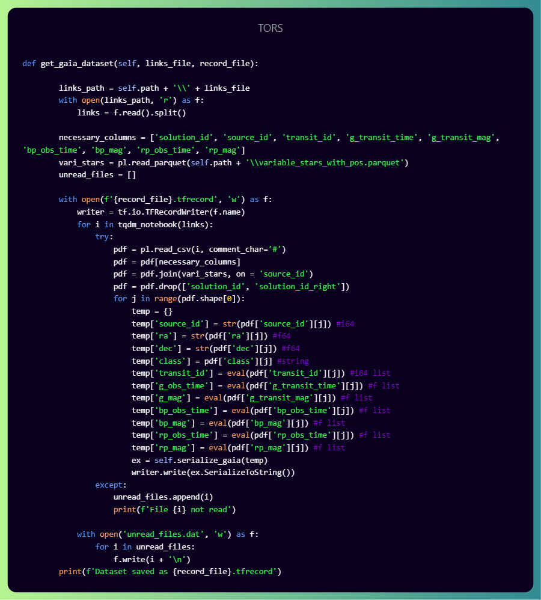

Here is an example of creating an instance of the created class TORS and calling the function to get the dataset for GAIA DR3.  
The extracted tfrecord file is of 5.88 GB, split in 2 parts for training and testing.

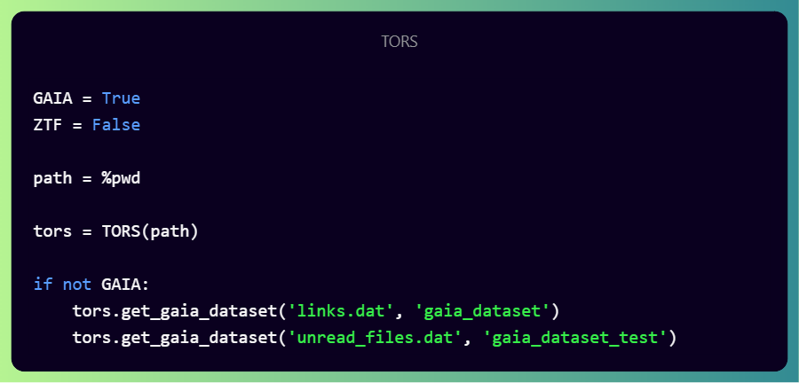

Reinforcement Learning Environment

Now, let's define an environment named TORS_RL to perform the recommendations.

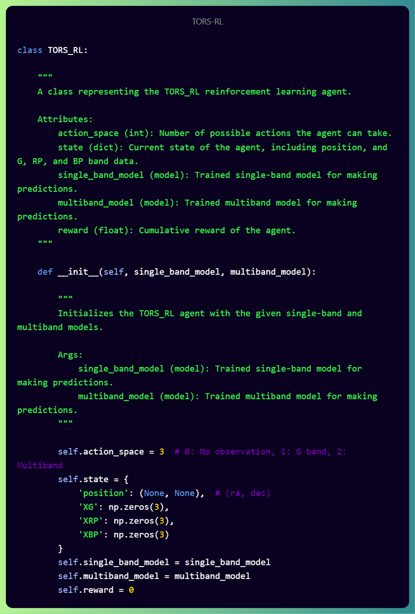

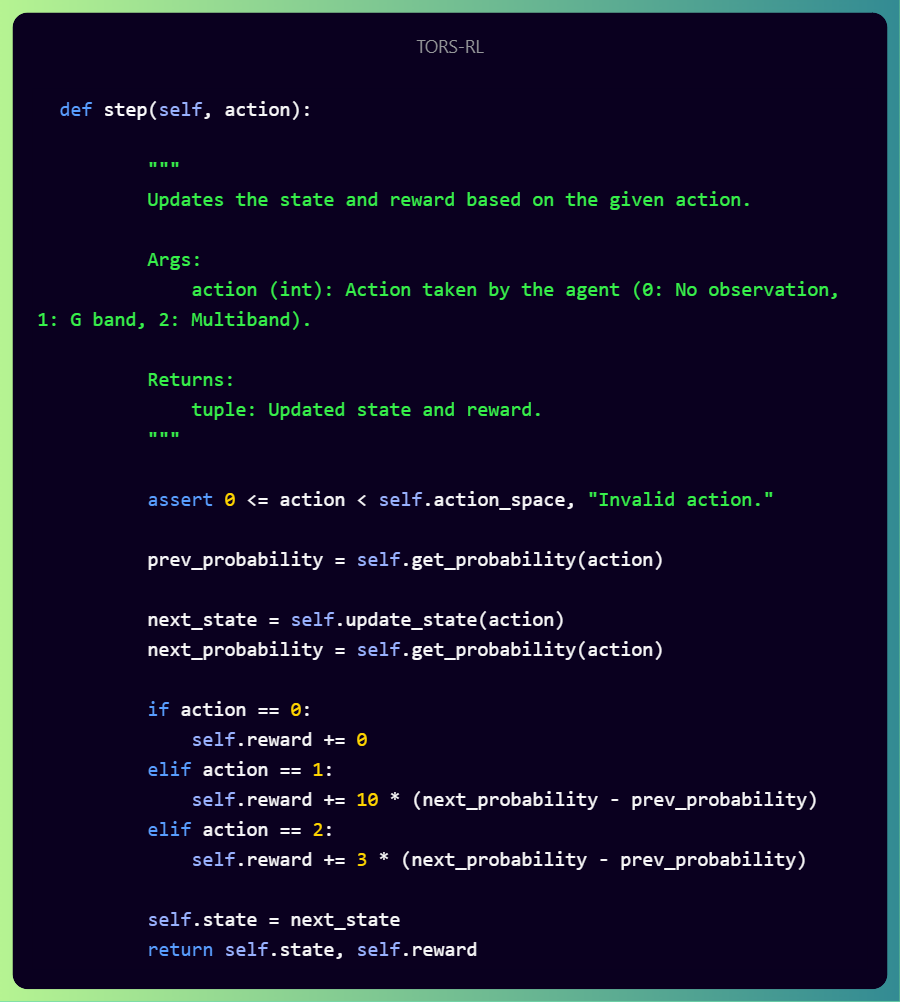

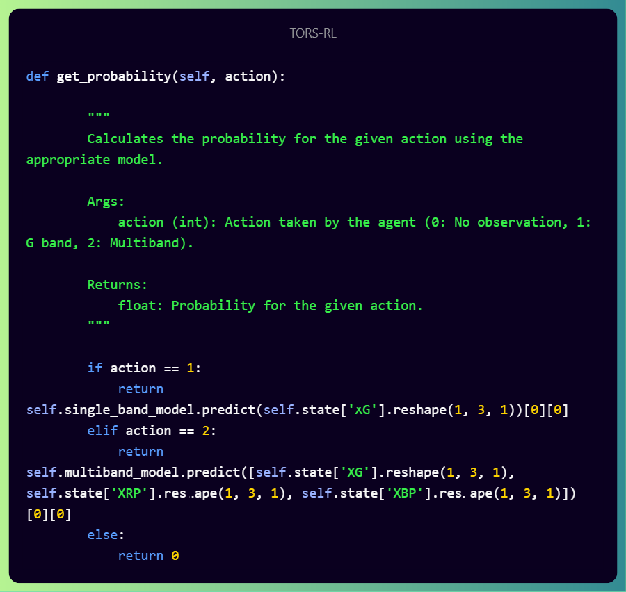

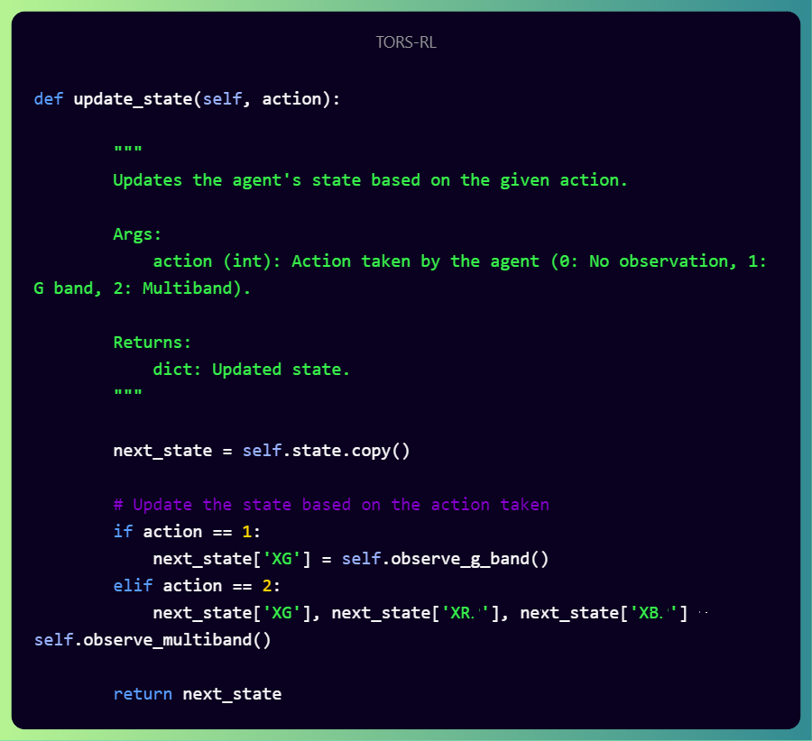

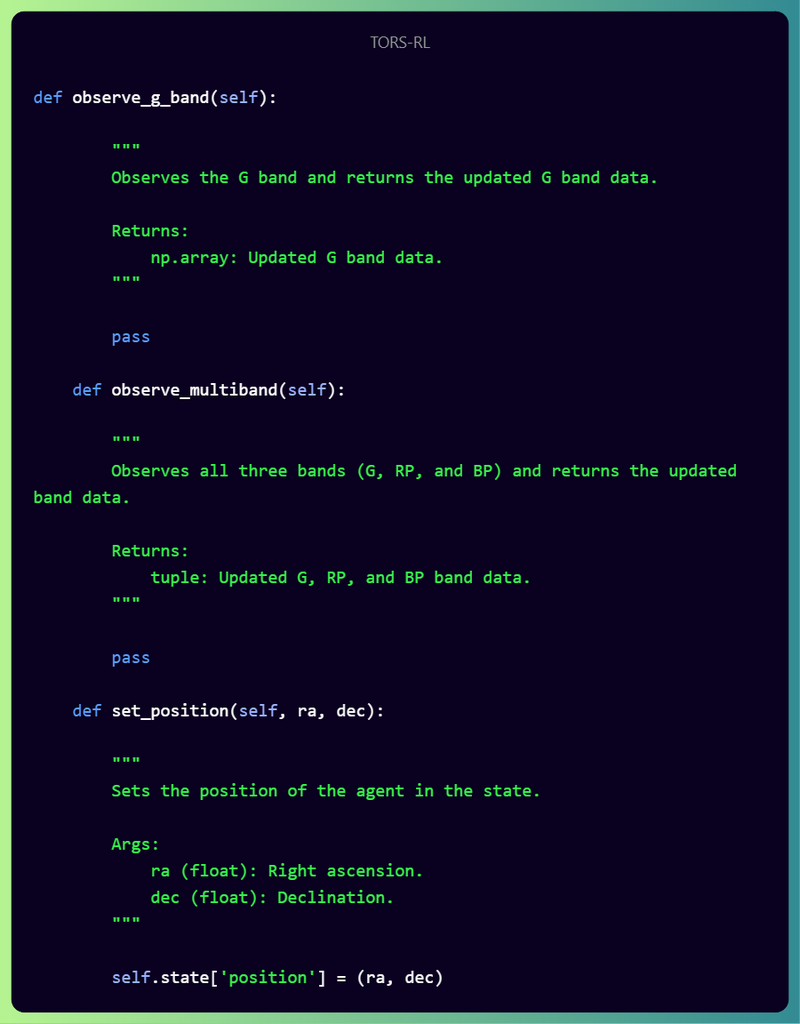

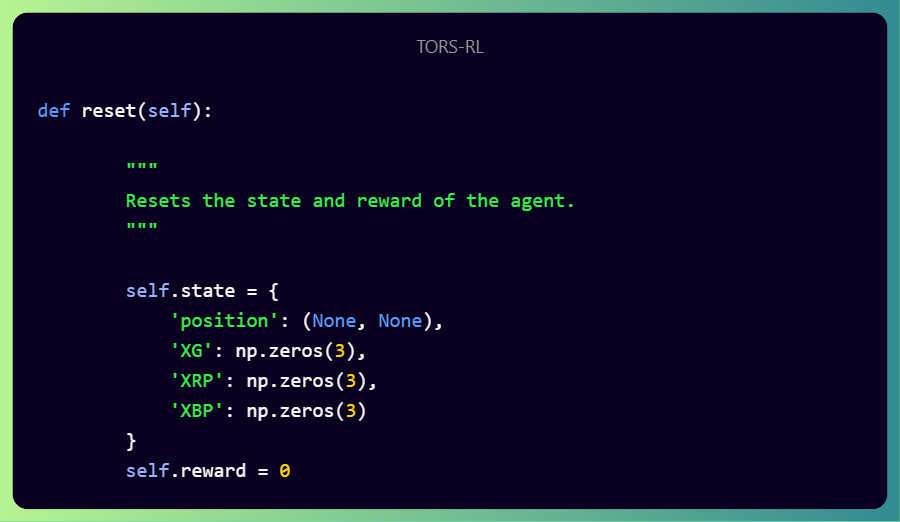

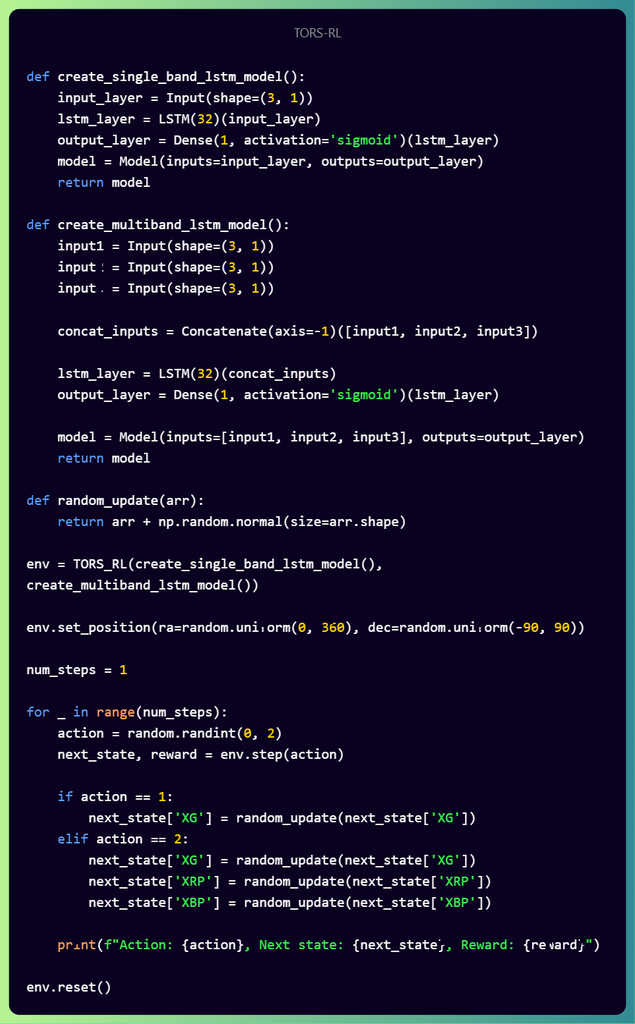

With this dummy example to start with, we conclude our navigation check submission.  
Next steps:

- Gather more data from different sources.
- Consolidate the lstm models to be used for classification. (This will be an extension of our AI-3 project which can be found [here](https://github.com/Lakshay-13/Classifying-Periodic-Variable-Stars).
- Change the reward function depending on the new extracted data.
- Use various techniques like DQN/DDQN to train the agent to perform recommendations.

References

- Images were generated using Bing's implementation of DALL.E
- Code Images were created using [this](https://codebeautify.org/code-to-image-converter).
- Lastly, special mention to Prof. Ignacio Becker to introduce us and guide us through the project.

[figure not shown]

# Code

This code section is a repitition of what we just showed as images.

```python
import gym
import time
import random
import versions
import matplotlib
import numpy as np
import pandas as pd
import polars as pl
from gym import Env
import tensorflow as tf
from tqdm import tqdm_notebook
from gym.spaces import Discrete, Box
from tensorflow.keras.models import Model
from tensorflow.keras.layers import Dense, LSTM, Input, Concatenate
```

```python
import warnings
warnings.filterwarnings('ignore')
```

```python
versions.check_imported_versions()
```

```
+---------------------+----------------+
|       Library       |    Version     |
+---------------------+----------------+
|         zipp        |     3.11.0     |
|  importlib_metadata |     6.0.0      |
|      setuptools     |     65.6.3     |
|        numpy        |     1.23.5     |
|         gym         |     0.19.0     |
|     prettytable     |     3.5.0      |
|      defusedxml     |     0.7.1      |
|         cffi        |     1.15.1     |
|      pyparsing      |     3.0.9      |
|        cycler       |     0.11.0     |
|      kiwisolver     |     1.4.4      |
|      matplotlib     |     3.7.1      |
|         pytz        |     2022.7     |
|  typing_extensions  |     4.4.0      |
|     cloudpickle     |     1.6.0      |
|       pyarrow       |     3.0.0      |
|       numexpr       |     2.8.4      |
|      bottleneck     |     1.3.5      |
|        pandas       |     1.5.3      |
|        polars       |    0.16.16     |
|        wrapt        |     1.14.1     |
|      opt_einsum     |     3.3.0      |
|         gast        |     0.4.0      |
|      astunparse     |     1.6.3      |
|      termcolor      |     2.1.0      |
| keras_preprocessing |     1.1.2      |
|        scipy        |     1.10.0     |
|       urllib3       |    1.26.14     |
|  charset_normalizer |     2.0.4      |
|         idna        |      3.4       |
|       certifi       |   2022.12.7    |
|       requests      |     2.28.1     |
|         h5py        |     3.7.0      |
|        pydot        |     1.4.1      |
|        tblib        |     1.7.0      |
|     flatbuffers     | 20210226132247 |
|     tensorboard     |     2.6.0      |
|      tensorflow     |     2.6.0      |
|         tqdm        |     4.65.0     |
|        keras        |     2.6.0      |
+---------------------+----------------+
```

```python
def eval(s):

    s = s.strip('[]').strip()
    string_list = s.split(',')
    float_list = [float(x) if x != 'NaN' else 999 for x in string_list]

    return float_list
```

```python
class TORS:

    def __init__(self, path):

        self.path = path

    def serialize_gaia(self, dictionary):

        dictionary_features={
        'id': tf.train.Feature(bytes_list=tf.train.BytesList(value=[str(dictionary['source_id']).encode()])),
        'ra': tf.train.Feature(bytes_list=tf.train.BytesList(value=[str(dictionary['ra']).encode()])),
        'dec': tf.train.Feature(bytes_list=tf.train.BytesList(value=[str(dictionary['dec']).encode()])),
        'class': tf.train.Feature(bytes_list=tf.train.BytesList(value=[str(dictionary['class']).encode()])),
        'transit_id': tf.train.Feature(float_list=tf.train.FloatList(value=dictionary['transit_id'])),
        'g_obs_time': tf.train.Feature(float_list=tf.train.FloatList(value=dictionary['g_obs_time'])),
        'g_mag': tf.train.Feature(float_list=tf.train.FloatList(value=dictionary['g_mag'])),
        'bp_obs_time': tf.train.Feature(float_list=tf.train.FloatList(value=dictionary['bp_obs_time'])),
        'bp_mag': tf.train.Feature(float_list=tf.train.FloatList(value=dictionary['bp_mag'])),
        'rp_obs_time': tf.train.Feature(float_list=tf.train.FloatList(value=dictionary['rp_obs_time'])),
        'rp_mag': tf.train.Feature(float_list=tf.train.FloatList(value=dictionary['rp_mag']))
        }


        element_context = tf.train.Features(feature = dictionary_features)

        example = tf.train.SequenceExample(context= element_context)

        return example

    def get_gaia_dataset(self, links_file, record_file):

        links_path = self.path + '\\' + links_file
        with open(links_path, 'r') as f:
            links = f.read().split()

        necessary_columns = ['solution_id', 'source_id', 'transit_id', 'g_transit_time', 'g_transit_mag', 'bp_obs_time', 'bp_mag', 'rp_obs_time', 'rp_mag']
        vari_stars = pl.read_parquet(self.path + '\\variable_stars_with_pos.parquet')
        unread_files = []

        with open(f'{record_file}.tfrecord', 'w') as f:
            writer = tf.io.TFRecordWriter(f.name)
            for i in tqdm_notebook(links):
                try:
                    pdf = pl.read_csv(i, comment_char='#')
                    pdf = pdf[necessary_columns]
                    pdf = pdf.join(vari_stars, on = 'source_id')
                    pdf = pdf.drop(['solution_id', 'solution_id_right'])
                    for j in range(pdf.shape[0]):
                        temp = {}
                        temp['source_id'] = str(pdf['source_id'][j]) #i64
                        temp['ra'] = str(pdf['ra'][j]) #f64
                        temp['dec'] = str(pdf['dec'][j]) #f64
                        temp['class'] = pdf['class'][j] #string
                        temp['transit_id'] = eval(pdf['transit_id'][j]) #i64 list
                        temp['g_obs_time'] = eval(pdf['g_transit_time'][j]) #f list
                        temp['g_mag'] = eval(pdf['g_transit_mag'][j]) #f list
                        temp['bp_obs_time'] = eval(pdf['bp_obs_time'][j]) #f list
                        temp['bp_mag'] = eval(pdf['bp_mag'][j]) #f list
                        temp['rp_obs_time'] = eval(pdf['rp_obs_time'][j]) #f list
                        temp['rp_mag'] = eval(pdf['rp_mag'][j]) #f list
                        ex = self.serialize_gaia(temp)
                        writer.write(ex.SerializeToString())
                except:
                    unread_files.append(i)
                    print(f'File {i} not read')

            with open('unread_files.dat', 'w') as f:
                for i in unread_files:
                    f.write(i + '\n')
        print(f'Dataset saved as {record_file}.tfrecord')
```

```python
GAIA = True
ZTF = False

path = %pwd

tors = TORS(path)

if not GAIA:
    tors.get_gaia_dataset('links.dat', 'gaia_dataset')
    tors.get_gaia_dataset('unread_files.dat', 'gaia_dataset_test')
```

```python
class TORS_RL:

    """
    A class representing the TORS_RL reinforcement learning agent.

    Attributes:
        action_space (int): Number of possible actions the agent can take.
        state (dict): Current state of the agent, including position, and G, RP, and BP band data.
        single_band_model (model): Trained single-band model for making predictions.
        multiband_model (model): Trained multiband model for making predictions.
        reward (float): Cumulative reward of the agent.
    """

    def __init__(self, single_band_model, multiband_model):

        """
        Initializes the TORS_RL agent with the given single-band and multiband models.

        Args:
            single_band_model (model): Trained single-band model for making predictions.
            multiband_model (model): Trained multiband model for making predictions.
        """

        self.action_space = 3  # 0: No observation, 1: G band, 2: Multiband
        self.state = {
            'position': (None, None),  # (ra, dec)
            'XG': np.zeros(3),
            'XRP': np.zeros(3),
            'XBP': np.zeros(3)
        }
        self.single_band_model = single_band_model
        self.multiband_model = multiband_model
        self.reward = 0

    def step(self, action):

        """
        Updates the state and reward based on the given action.

        Args:
            action (int): Action taken by the agent (0: No observation, 1: G band, 2: Multiband).

        Returns:
            tuple: Updated state and reward.
        """

        assert 0 <= action < self.action_space, "Invalid action."

        prev_probability = self.get_probability(action)

        next_state = self.update_state(action)
        next_probability = self.get_probability(action)

        if action == 0:
            self.reward += 0
        elif action == 1:
            self.reward += 10 * (next_probability - prev_probability)
        elif action == 2:
            self.reward += 3 * (next_probability - prev_probability)

        self.state = next_state
        return self.state, self.reward

    def get_probability(self, action):

        """
        Calculates the probability for the given action using the appropriate model.

        Args:
            action (int): Action taken by the agent (0: No observation, 1: G band, 2: Multiband).

        Returns:
            float: Probability for the given action.
        """

        if action == 1:
            return self.single_band_model.predict(self.state['XG'].reshape(1, 3, 1))[0][0]
        elif action == 2:
            return self.multiband_model.predict([self.state['XG'].reshape(1, 3, 1), self.state['XRP'].reshape(1, 3, 1), self.state['XBP'].reshape(1, 3, 1)])[0][0]
        else:
            return 0

    def update_state(self, action):

        """
        Updates the agent's state based on the given action.

        Args:
            action (int): Action taken by the agent (0: No observation, 1: G band, 2: Multiband).

        Returns:
            dict: Updated state.
        """

        next_state = self.state.copy()

        # Update the state based on the action taken
        if action == 1:
            next_state['XG'] = self.observe_g_band()
        elif action == 2:
            next_state['XG'], next_state['XRP'], next_state['XBP'] = self.observe_multiband()

        return next_state

    def observe_g_band(self):

        """
        Observes the G band and returns the updated G band data.

        Returns:
            np.array: Updated G band data.
        """

        return np.zeros(3)

    def observe_multiband(self):

        """
        Observes all three bands (G, RP, and BP) and returns the updated band data.

        Returns:
            tuple: Updated G, RP, and BP band data.
        """

        return (np.zeros(3),np.zeros(3),np.zeros(3))

    def set_position(self, ra, dec):

        """
        Sets the position of the agent in the state.

        Args:
            ra (float): Right ascension.
            dec (float): Declination.
        """

        self.state['position'] = (ra, dec)

    def reset(self):

        """
        Resets the state and reward of the agent.
        """

        self.state = {
            'position': (None, None),
            'XG': np.zeros(3),
            'XRP': np.zeros(3),
            'XBP': np.zeros(3)
        }
        self.reward = 0
```

```python
def create_single_band_lstm_model():
    input_layer = Input(shape=(3, 1))
    lstm_layer = LSTM(32)(input_layer)
    output_layer = Dense(1, activation='sigmoid')(lstm_layer)
    model = Model(inputs=input_layer, outputs=output_layer)
    return model

def create_multiband_lstm_model():
    input1 = Input(shape=(3, 1))
    input2 = Input(shape=(3, 1))
    input3 = Input(shape=(3, 1))

    concat_inputs = Concatenate(axis=-1)([input1, input2, input3])

    lstm_layer = LSTM(32)(concat_inputs)
    output_layer = Dense(1, activation='sigmoid')(lstm_layer)

    model = Model(inputs=[input1, input2, input3], outputs=output_layer)
    return model

def random_update(arr):
    return arr + np.random.normal(size=arr.shape)

env = TORS_RL(create_single_band_lstm_model(), create_multiband_lstm_model())

env.set_position(ra=random.uniform(0, 360), dec=random.uniform(-90, 90))

num_steps = 1

for _ in range(num_steps):
    action = random.randint(0, 2)
    next_state, reward = env.step(action)

    if action == 1:
        next_state['XG'] = random_update(next_state['XG'])
    elif action == 2:
        next_state['XG'] = random_update(next_state['XG'])
        next_state['XRP'] = random_update(next_state['XRP'])
        next_state['XBP'] = random_update(next_state['XBP'])

    print(f"Action: {action}, Next state: {next_state}, Reward: {reward}")

env.reset()
```

```
Action: 0, Next state: {'position': (262.6986389846635, 52.877268754286746), 'XG': array([0., 0., 0.]), 'XRP': array([0., 0., 0.]), 'XBP': array([0., 0., 0.])}, Reward: 0
```